# Medical Flower Price Report

Value Analysis for Magic City Cannabis - Colorado

## Magic City Cannabis - Colorado

3819 Quentin St,  
Denver, Colorado

**Rating:** 4.9⭐ (454 reviews)

**Phone:** (720) 692-1539

**Menu:** [View Menu](https://weedmaps.com/dispensaries/magic-city-cannabis-colorado)

## Executive Summary

Cheapest ounce-equivalent (28g)

$48.20/oz

Cutting Edge - GG4

28g • $47.46

Typical price (per product, 28g norm)

$65/oz

IQR $37–$108

Low-price coverage (28g)

40% ≤ $60/oz

64% ≤ $90/oz

💰 Largest bulk savings

51%

Cutting Edge - GG4

1g @ $99/oz → 28g @ $48/oz

Bottom line: Mixed value (25–49% of products ≤ $60/oz, 28g norm)

### Category medians & counts

Shake/Popcorn/Trim

min $29 • 20 products

Pre-Pack Specialty

min $68 • 5 products

Bulk Value

min $48 • 17 products

### Price band coverage (per product)

≤ $60 (28g)

17 (40%)

$61–$90 (28g)

10 (24%)

$91–$120 (28g)

6 (14%)

$121–$200 (28g)

7 (17%)

>$200 (28g)

2 (5%)

#### ≤ $60

| Product | Category | Best Size | Best Price | Best $/Oz (28g) |
| --- | --- | --- | --- | --- |
| Cutting Edge - GG4 | Bulk Value | 28g | $47.46 | $48.20 |
| Cutting Edge - Oreoz | Bulk Value | 28g | $47.46 | $48.20 |

#### $61–$90

| Product | Category | Best Size | Best Price | Best $/Oz (28g) |
| --- | --- | --- | --- | --- |
| Magic City Cannabis (In House) - Banana Pancake #8 | Pre-Pack Specialty | 28g | $67.05 | $67.76 |
| Magic City Cannabis (In House) - Fried Strawberry | Pre-Pack Specialty | 28g | $67.05 | $67.76 |
| Magic City Cannabis (In House) - Wet Wet | Bulk Value | 28g | $71.10 | $72.01 |
| Magic City Cannabis (In House) - Pink Zkittlez | Bulk Value | 28g | $87.30 | $88.45 |
| Magic City Cannabis (In House) Papaya Juice | Bulk Value | 28g | $87.30 | $88.45 |

#### $91–$120

| Product | Category | Best Size | Best Price | Best $/Oz (28g) |
| --- | --- | --- | --- | --- |
| Magic City Cannabis (In House) - Mochi | Pre-Pack Specialty | 28g | $91.91 | $92.99 |
| Magic City Cannabis (In House) - Banana Pancake #7 | Bulk Value | 28g | $105.21 | $106.60 |
| Magic City Cannabis (In House) - Dosido | Bulk Value | 28g | $106.60 | $108.01 |
| Magic City Cannabis (In House) - Gary Payton | Bulk Value | 28g | $106.60 | $108.01 |
| Magic City Cannabis (In House) - Keanu Reeves | Bulk Value | 28g | $106.60 | $108.01 |
| Magic City Cannabis (In House) - Zkittlez x Kush Mintz | Bulk Value | 28g | $106.60 | $108.01 |

#### $121–$200

| Product | Category | Best Size | Best Price | Best $/Oz (28g) |
| --- | --- | --- | --- | --- |
| Magic City Cannabis (In House) - Dirty Taxi | Bulk Value | 28g | $124.06 | $125.59 |
| Magic City Cannabis (In House) - Gelato Cake | Bulk Value | 28g | $124.06 | $125.59 |
| Magic City Cannabis (In House) - Gelato Punch | Bulk Value | 28g | $124.06 | $125.59 |
| Magic City Cannabis (In House) - Lickz | Bulk Value | 28g | $124.06 | $125.59 |
| Magic City Cannabis (In House) - Soap | Bulk Value | 14g | $62.03 | $125.59 |
| Magic City Cannabis (In House) - Apricot Scone | Bulk Value | 28g | $147.04 | $148.84 |
| Magic City Cannabis (In House) - Candy Bezels | Bulk Value | 7g | $43.47 | $176.05 |

#### >$200

| Product | Category | Best Size | Best Price | Best $/Oz (28g) |
| --- | --- | --- | --- | --- |
| Magic City Cannabis (In House) - Candy Bezels 1/8 Pre Pack | Pre-Pack Specialty | 3.5g | $25.00 | $202.42 |
| Kaviar Moonrocks \| Sativa - 1g | Pre-Pack Specialty | 1g | $22.00 | $623.70 |

🥇

Cutting Edge - GG4

Bulk Value • 28g • $47.46

$48.20/oz

28g normalized

🥈

Cutting Edge - Oreoz

Bulk Value • 28g • $47.46

$48.20/oz

28g normalized

🥉

Magic City Cannabis (In House) - Fried S...

Pre-Pack Specialty • 28g • $67.05

$67.76/oz

28g normalized

## Price Distribution Visuals

### Box Plot (quartiles + whiskers)

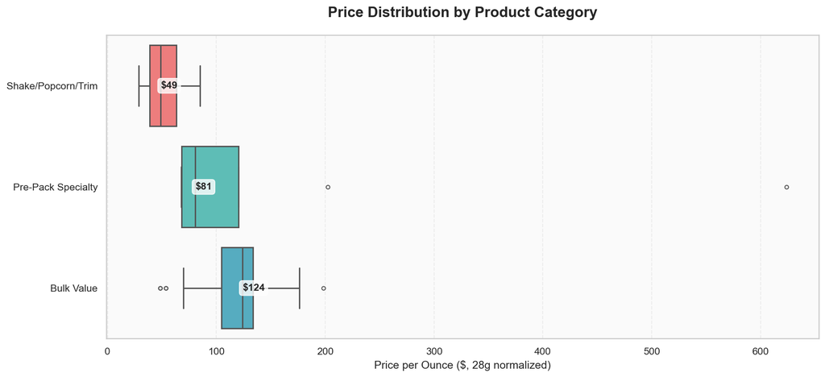

### ECDF Overlay (cumulative comparison)

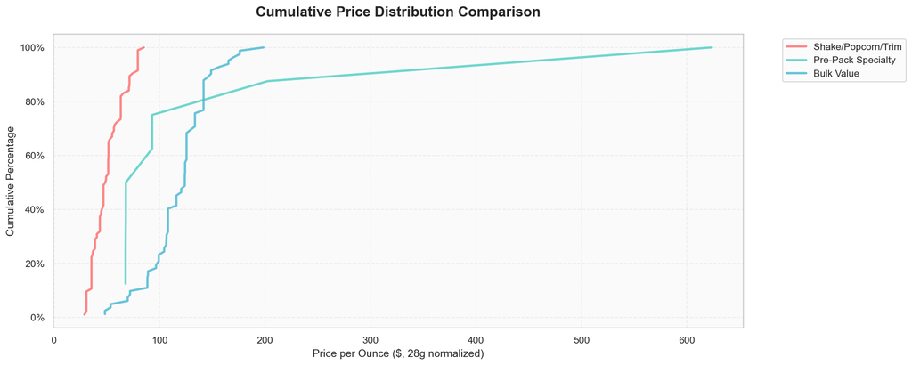

## 💸 Shake/Popcorn/Trim

| name | size_label | price | price_per_oz | Efficient Sizes | Max Savings vs Smallest |
| --- | --- | --- | --- | --- | --- |
| Magic City Cannabis (In House) - Fried Strawberry Shake | 7g | $7.05 | $28.63 | 1g → 3.5g → 7g | 22% |
| Magic City Cannabis (In House) - Keanu Reeves Shake | 28g | $30.32 | $30.62 | 1g → 7g → 14g | 35% |
| Magic City Cannabis (In House) - Key Lime Pie Shake | 28g | $30.32 | $30.62 | 1g → 7g → 14g | 35% |
| Magic City Cannabis (In House) - Peanut Butter Souffle Shake | 28g | $30.32 | $30.62 | 1g → 7g → 14g | 35% |
| Magic City Cannabis (In House) - Permanent Marker Shake | 28g | $30.32 | $30.62 | 1g → 7g → 14g | 35% |
| Magic City Cannabis (In House) - Gelato Cake Shake | 28g | $34.91 | $35.44 | 1g → 7g → 14g | 31% |
| Magic City Cannabis (In House) - Gelato Punch Shake | 28g | $34.91 | $35.44 | 1g → 7g → 14g | 31% |
| Magic City Cannabis (In House) - Lickz Shake | 28g | $34.91 | $35.44 | 1g → 7g → 14g | 31% |
| Magic City Cannabis (In House) - Pink Zkittlez Shake | 28g | $34.91 | $35.44 | 1g → 7g → 14g | 31% |
| Magic City Cannabis (In House) - Soap Shake | 28g | $34.91 | $35.44 | 1g → 7g → 14g | 31% |
| Magic City Cannabis (In House) - Zkittlez x Kush Mintz Shake | 28g | $34.91 | $35.44 | 1g → 7g → 14g | 31% |
| Magic City Cannabis (In House) - Dirty Taxi Shake | 28g | $39.99 | $40.54 | 1g → 3.5g → 7g → 14g | 29% |
| Magic City Cannabis (In House) - Candy Bezels Shake | 28g | $44.30 | $44.79 | 1g → 3.5g → 7g → 14g → 28g | 25% |
| Magic City Cannabis (In House) Papaya Juice Popcorn | 28g | $48.70 | $49.33 | 1g → 3.5g → 7g → 14g | 42% |
| Magic City Cannabis (In House) - Keanu Reeves Popcorn | 28g | $54.21 | $55.00 | 1g → 7g → 14g | 22% |
| Magic City Cannabis (In House) - Fried Strawberry Popcorn | 28g | $62.48 | $63.22 | 1g → 7g → 14g | 20% |
| Magic City Cannabis (In House) - Lickz Popcorn | 28g | $62.48 | $63.22 | 1g → 7g → 14g | 20% |
| Magic City Cannabis (In House) - Pink Zkittlez Popcorn | 28g | $62.48 | $63.22 | 1g → 7g → 14g | 20% |
| Magic City Cannabis (In House) - Zkittlez x Kush Mintz Popcorn | 28g | $62.48 | $63.22 | 1g → 7g → 14g | 20% |
| Magic City Cannabis - Joint (Shake) (Deli Style) Fried Strawberry .6g | 0.6g | $1.58 | $74.56 | 0.6g | NaN |

## 💎 Pre-Pack Specialty

| name | size_label | price | price_per_oz | Efficient Sizes | Max Savings vs Smallest |
| --- | --- | --- | --- | --- | --- |
| Magic City Cannabis (In House) - Banana Pancake #8 | 28g | $67.05 | $67.76 | 14g → 28g | 0% |
| Magic City Cannabis (In House) - Fried Strawberry | 28g | $67.05 | $67.76 | 14g → 28g | 0% |
| Magic City Cannabis (In House) - Mochi | 28g | $91.91 | $92.99 | 14g | NaN |
| Magic City Cannabis (In House) - Candy Bezels 1/8 Pre Pack | 3.5g | $25.00 | $202.42 | 3.5g | NaN |
| Kaviar Moonrocks \| Sativa - 1g | 1g | $22.00 | $623.70 | 1g | NaN |

## 🏆 Bulk Value

| name | size_label | price | price_per_oz | Efficient Sizes | Max Savings vs Smallest |
| --- | --- | --- | --- | --- | --- |
| Cutting Edge - GG4 | 28g | $47.46 | $48.20 | 1g → 3.5g → 7g → 14g → 28g | 51% |
| Cutting Edge - Oreoz | 28g | $47.46 | $48.20 | 1g → 3.5g → 7g → 14g → 28g | 51% |
| Magic City Cannabis (In House) - Wet Wet | 28g | $71.10 | $72.01 | 1g → 7g → 14g | 32% |
| Magic City Cannabis (In House) - Pink Zkittlez | 28g | $87.30 | $88.45 | 1g → 3.5g → 7g → 14g | 27% |
| Magic City Cannabis (In House) Papaya Juice | 28g | $87.30 | $88.45 | 1g → 3.5g → 7g → 14g | 27% |
| Magic City Cannabis (In House) - Banana Pancake #7 | 28g | $105.21 | $106.60 | 1g → 3.5g → 7g → 14g | 37% |
| Magic City Cannabis (In House) - Dosido | 28g | $106.60 | $108.01 | 1g → 7g → 14g | 13% |
| Magic City Cannabis (In House) - Gary Payton | 28g | $106.60 | $108.01 | 1g → 7g → 14g | 13% |
| Magic City Cannabis (In House) - Keanu Reeves | 28g | $106.60 | $108.01 | 1g → 7g → 14g | 13% |
| Magic City Cannabis (In House) - Zkittlez x Kush Mintz | 28g | $106.60 | $108.01 | 1g → 7g → 14g | 13% |
| Magic City Cannabis (In House) - Dirty Taxi | 28g | $124.06 | $125.59 | 1g → 7g → 14g | 11% |
| Magic City Cannabis (In House) - Gelato Cake | 28g | $124.06 | $125.59 | 1g → 7g → 14g | 11% |
| Magic City Cannabis (In House) - Gelato Punch | 28g | $124.06 | $125.59 | 1g → 7g → 14g | 11% |
| Magic City Cannabis (In House) - Lickz | 28g | $124.06 | $125.59 | 1g → 7g → 14g | 11% |
| Magic City Cannabis (In House) - Soap | 14g | $62.03 | $125.59 | 1g → 7g → 14g | 11% |
| Magic City Cannabis (In House) - Apricot Scone | 28g | $147.04 | $148.84 | 1g → 14g | 5% |
| Magic City Cannabis (In House) - Candy Bezels | 7g | $43.47 | $176.05 | 1g → 3.5g | 11% |

## Bulk Savings Spotlight — Full Detail

| Product | Category | Small Size | Small (g) | Small Price | Small $/oz (28g) | Large Size | Large (g) | Large Price | Large $/oz (28g) | Savings % | Δ $/oz (28g) |
| --- | --- | --- | --- | --- | --- | --- | --- | --- | --- | --- | --- |
| Cutting Edge - GG4 | Bulk Value | 1g | 1g | $3.50 | $99.23 | 28g | 28.35g | $47.46 | $48.20 | 51% | $51.03 |
| Cutting Edge - Oreoz | Bulk Value | 1g | 1g | $3.50 | $99.23 | 28g | 28.35g | $47.46 | $48.20 | 51% | $51.03 |
| Magic City Cannabis (In House) Papaya Juice Popcorn | Shake/Popcorn/Trim | 1g | 1g | $3.00 | $85.05 | 28g | 28.35g | $48.70 | $49.33 | 42% | $35.72 |
| Magic City Cannabis (In House) - Banana Pancake #7 | Bulk Value | 1g | 1g | $6.00 | $170.10 | 28g | 28.35g | $105.21 | $106.60 | 37% | $63.50 |
| Magic City Cannabis (In House) - Key Lime Pie Shake | Shake/Popcorn/Trim | 1g | 1g | $1.65 | $46.78 | 28g | 28.35g | $30.32 | $30.62 | 35% | $16.16 |
| Magic City Cannabis (In House) - Peanut Butter Souffle Shake | Shake/Popcorn/Trim | 1g | 1g | $1.65 | $46.78 | 28g | 28.35g | $30.32 | $30.62 | 35% | $16.16 |
| Magic City Cannabis (In House) - Permanent Marker Shake | Shake/Popcorn/Trim | 1g | 1g | $1.65 | $46.78 | 28g | 28.35g | $30.32 | $30.62 | 35% | $16.16 |
| Magic City Cannabis (In House) - Keanu Reeves Shake | Shake/Popcorn/Trim | 1g | 1g | $1.65 | $46.78 | 28g | 28.35g | $30.32 | $30.62 | 35% | $16.16 |
| Magic City Cannabis (In House) - Wet Wet | Bulk Value | 1g | 1g | $3.75 | $106.31 | 28g | 28.35g | $71.10 | $72.01 | 32% | $34.30 |
| Magic City Cannabis (In House) - Soap Shake | Shake/Popcorn/Trim | 1g | 1g | $1.81 | $51.31 | 28g | 28.35g | $34.91 | $35.44 | 31% | $15.88 |
| Magic City Cannabis (In House) - Lickz Shake | Shake/Popcorn/Trim | 1g | 1g | $1.81 | $51.31 | 28g | 28.35g | $34.91 | $35.44 | 31% | $15.88 |
| Magic City Cannabis (In House) - Pink Zkittlez Shake | Shake/Popcorn/Trim | 1g | 1g | $1.81 | $51.31 | 28g | 28.35g | $34.91 | $35.44 | 31% | $15.88 |
| Magic City Cannabis (In House) - Gelato Punch Shake | Shake/Popcorn/Trim | 1g | 1g | $1.81 | $51.31 | 28g | 28.35g | $34.91 | $35.44 | 31% | $15.88 |
| Magic City Cannabis (In House) - Gelato Cake Shake | Shake/Popcorn/Trim | 1g | 1g | $1.81 | $51.31 | 28g | 28.35g | $34.91 | $35.44 | 31% | $15.88 |
| Magic City Cannabis (In House) - Zkittlez x Kush Mintz Shake | Shake/Popcorn/Trim | 1g | 1g | $1.81 | $51.31 | 28g | 28.35g | $34.91 | $35.44 | 31% | $15.88 |
| Magic City Cannabis (In House) - Dirty Taxi Shake | Shake/Popcorn/Trim | 1g | 1g | $2.00 | $56.70 | 28g | 28.35g | $39.99 | $40.54 | 29% | $16.16 |
| Magic City Cannabis (In House) - Pink Zkittlez | Bulk Value | 1g | 1g | $4.25 | $120.49 | 28g | 28.35g | $87.30 | $88.45 | 27% | $32.04 |
| Magic City Cannabis (In House) Papaya Juice | Bulk Value | 1g | 1g | $4.25 | $120.49 | 28g | 28.35g | $87.30 | $88.45 | 27% | $32.04 |
| Magic City Cannabis (In House) - Candy Bezels Shake | Shake/Popcorn/Trim | 1g | 1g | $2.10 | $59.54 | 28g | 28.35g | $44.30 | $44.79 | 25% | $14.74 |
| Magic City Cannabis (In House) - Keanu Reeves Popcorn | Shake/Popcorn/Trim | 1g | 1g | $2.50 | $70.88 | 28g | 28.35g | $54.21 | $55.00 | 22% | $15.88 |
| Magic City Cannabis (In House) - Fried Strawberry Shake | Shake/Popcorn/Trim | 1g | 1g | $1.30 | $36.86 | 7g | 7.0875g | $7.05 | $28.63 | 22% | $8.22 |
| Magic City Cannabis (In House) - Lickz Popcorn | Shake/Popcorn/Trim | 1g | 1g | $2.80 | $79.38 | 28g | 28.35g | $62.48 | $63.22 | 20% | $16.16 |
| Magic City Cannabis (In House) - Zkittlez x Kush Mintz Popcorn | Shake/Popcorn/Trim | 1g | 1g | $2.80 | $79.38 | 28g | 28.35g | $62.48 | $63.22 | 20% | $16.16 |
| Magic City Cannabis (In House) - Fried Strawberry Popcorn | Shake/Popcorn/Trim | 1g | 1g | $2.80 | $79.38 | 28g | 28.35g | $62.48 | $63.22 | 20% | $16.16 |
| Magic City Cannabis (In House) - Pink Zkittlez Popcorn | Shake/Popcorn/Trim | 1g | 1g | $2.80 | $79.38 | 28g | 28.35g | $62.48 | $63.22 | 20% | $16.16 |
| Magic City Cannabis (In House) - Keanu Reeves | Bulk Value | 1g | 1g | $4.37 | $123.89 | 28g | 28.35g | $106.60 | $108.01 | 13% | $15.88 |
| Magic City Cannabis (In House) - Gary Payton | Bulk Value | 1g | 1g | $4.37 | $123.89 | 28g | 28.35g | $106.60 | $108.01 | 13% | $15.88 |
| Magic City Cannabis (In House) - Zkittlez x Kush Mintz | Bulk Value | 1g | 1g | $4.37 | $123.89 | 28g | 28.35g | $106.60 | $108.01 | 13% | $15.88 |
| Magic City Cannabis (In House) - Dosido | Bulk Value | 1g | 1g | $4.37 | $123.89 | 28g | 28.35g | $106.60 | $108.01 | 13% | $15.88 |
| Magic City Cannabis (In House) - Dirty Taxi | Bulk Value | 1g | 1g | $5.00 | $141.75 | 28g | 28.35g | $124.06 | $125.59 | 11% | $16.16 |
| Magic City Cannabis (In House) - Lickz | Bulk Value | 1g | 1g | $5.00 | $141.75 | 28g | 28.35g | $124.06 | $125.59 | 11% | $16.16 |
| Magic City Cannabis (In House) - Gelato Cake | Bulk Value | 1g | 1g | $5.00 | $141.75 | 28g | 28.35g | $124.06 | $125.59 | 11% | $16.16 |
| Magic City Cannabis (In House) - Soap | Bulk Value | 1g | 1g | $5.00 | $141.75 | 14g | 14.175g | $62.03 | $125.59 | 11% | $16.16 |
| Magic City Cannabis (In House) - Gelato Punch | Bulk Value | 1g | 1g | $5.00 | $141.75 | 28g | 28.35g | $124.06 | $125.59 | 11% | $16.16 |
| Magic City Cannabis (In House) - Candy Bezels | Bulk Value | 1g | 1g | $7.00 | $198.45 | 7g | 7.0875g | $43.47 | $176.05 | 11% | $22.40 |
| Magic City Cannabis (In House) - Apricot Scone | Bulk Value | 1g | 1g | $5.50 | $155.93 | 28g | 28.35g | $147.04 | $148.84 | 5% | $7.09 |
| Magic City Cannabis (In House) - Banana Pancake #8 | Pre-Pack Specialty | 14g | 14.175g | $33.60 | $68.04 | 28g | 28.35g | $67.05 | $67.76 | 0% | $0.28 |
| Magic City Cannabis (In House) - Fried Strawberry | Pre-Pack Specialty | 14g | 14.175g | $33.60 | $68.04 | 28g | 28.35g | $67.05 | $67.76 | 0% | $0.28 |